# Verneuil Disease_Analysis

Nansseu JR

2025-10-23

# Présentation

Cette analyse présente les résultats d’une étude transversale descriptive sur le profil épidémiologique et clinique de la **Maladie de Verneuil** au sein d’une population noire africaine. Les analyses sont faites à l’aide de R version 4.5.1 (R Core Team, 2025, R Foundation for Statistical Computing, Vienna, Austria)[ref](https://www.R-project.org/). Les données qualitatives sont résumées par les fréquences et pourcentages. tandis que les données quantitatives le sont par la moyenne +/- écart-type (ET) ou médiane (intervalle inter-quartile) selon que la variable suit ou non une distribution normale. La normalité a été évaluée par le test de Shapiro-Wilk. Tableaux et figures servent à la présentation de ces résumés. Le test non-paramétrique de Wilcoxon a été utilisé pour la comparaison de variables quantitatives, avec un seuil de significativé fixé à p < 0,05.

# Importation des packages et de la base des données

La base de données importée dispose de 35 variables pour 49 observations. Les analyses qui suivent sont donc présentées pour un total de **49 patients**.

# Configuration des données

Le tableau ci-dessous présente les différentes fréquences absolues et pourcentages de chaque modalité des variables renseignées.

| Characteristic | N = 491 |
| --- | --- |
| age_annees | 35 (28, 40) |
| sexe |  |
| Féminin | 29 (59%) |
| Masculin | 20 (41%) |
| collecte_de_donnees |  |
| Prospective | 20 (41%) |
| Retrospective | 29 (59%) |
| hopital_de_recrutement |  |
| CHUD PARAKOU | 5 (10%) |
| chud_parakou | 1 (2.0%) |
| CNHU | 19 (39%) |
| HCY | 24 (49%) |
| profession |  |
| Artisans et ouvriers( maçons, charpentier, platriers etc) | 8 (19%) |
| Élève/Étudiant | 11 (26%) |
| Employés administratifs( secrétaires, guichetiers) | 8 (19%) |
| Ouvriers et employés non qualifiés (aide ménage, vendeur ambulant) | 3 (7.1%) |
| Personnel des services, de vente | 5 (12%) |
| Professions intellectuelles (ingénieur, médecin, enseignant etc) | 7 (17%) |
| Unknown | 7 |
| motif_de_consultation |  |
| Douleur(préciser l'intensité) | 2 (4.1%) |
| Douleur(préciser l'intensité) Lésions liquidiennes | 5 (10%) |
| Douleur(préciser l'intensité) Lésions solides | 13 (27%) |
| Écoulement purulent | 1 (2.0%) |
| Lésions liquidiennes | 5 (10%) |
| Lésions liquidiennes Écoulement purulent | 1 (2.0%) |
| Lésions solides | 18 (37%) |
| Lésions solides Écoulement purulent | 3 (6.1%) |
| Lésions solides Lésions liquidiennes | 1 (2.0%) |

[output cut: 201 more lines]

1Median (Q1, Q3); n (%)

# Analyses univariées

## Distribution d’âge et sexe

```
##
##  Shapiro-Wilk normality test
##
## data:  mdv$age_annees
## W = 0.98525, p-value = 0.7918
```

```
##    Min. 1st Qu.  Median    Mean 3rd Qu.    Max.
##   10.00   28.00   35.00   34.45   40.00   63.00
```

```
## [1] 10.22061
```

| tranche_age | n | pct |
| --- | --- | --- |
| 10-19 | 2 | 4.1 |
| 20-29 | 13 | 26.5 |
| 30-39 | 21 | 42.9 |
| 40-49 | 10 | 20.4 |
| 50-59 | 2 | 4.1 |
| 60+ | 1 | 2 |

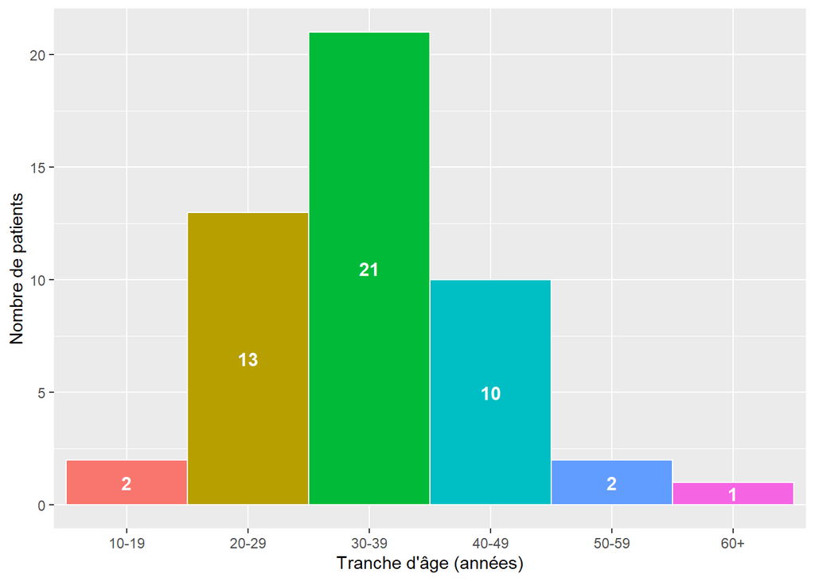

Les âges des patients varient de 10 à 63 ans, avec une moyenne de 34,5 +/- 10,2 ans. La tranche d’âge la plus représentée est celle des 30-39 ans (n = 21; 42,9%), suivie des 20-29 ans (n = 13; 26,5%).

Les femmes (n = 29; 59,2%)) représentent près de 3/5 des patients.

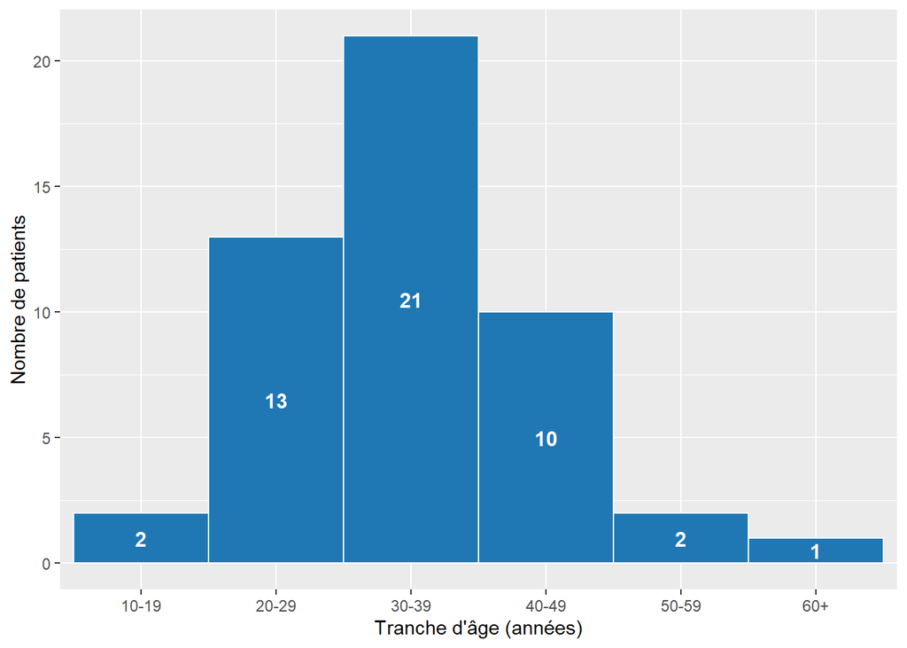

## Motifs de consultation

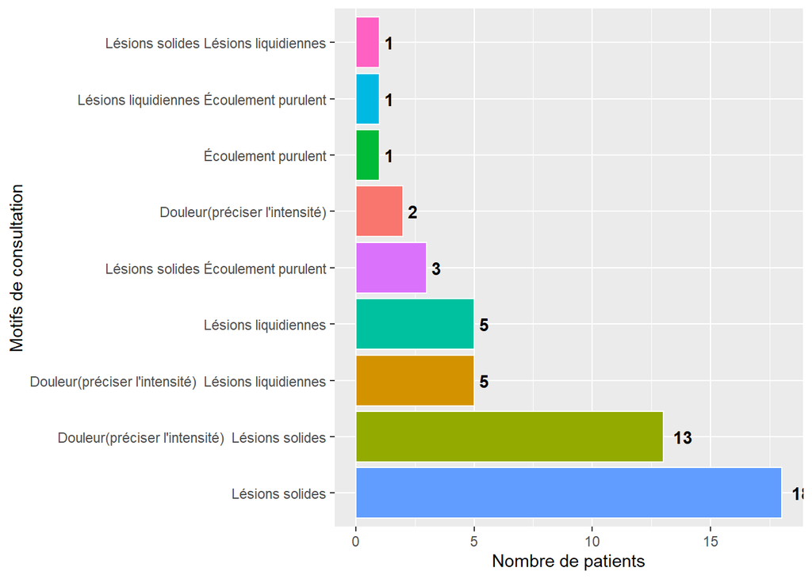

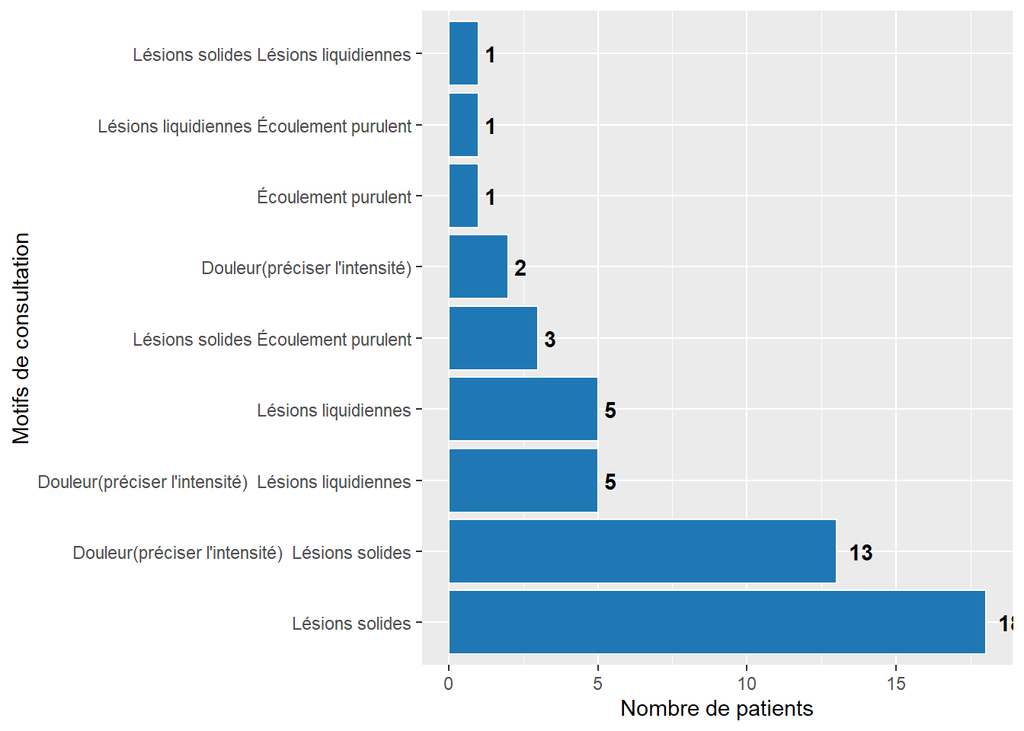

## Délai d’évolution

```
##
##  Shapiro-Wilk normality test
##
## data:  mdv$delai_devolution_en_mois
## W = 0.83295, p-value = 1.999e-05
```

```
##    Min. 1st Qu.  Median    Mean 3rd Qu.    Max.    NA's
##    0.00    7.00   24.00   31.44   48.00  120.00       6
```

Pour les 43 patients dont les données sont disponibles, le délai d’évolution de la maladie varie de 0 à 120 mois, avec une médiane de 24 mois (IQR 7-48).

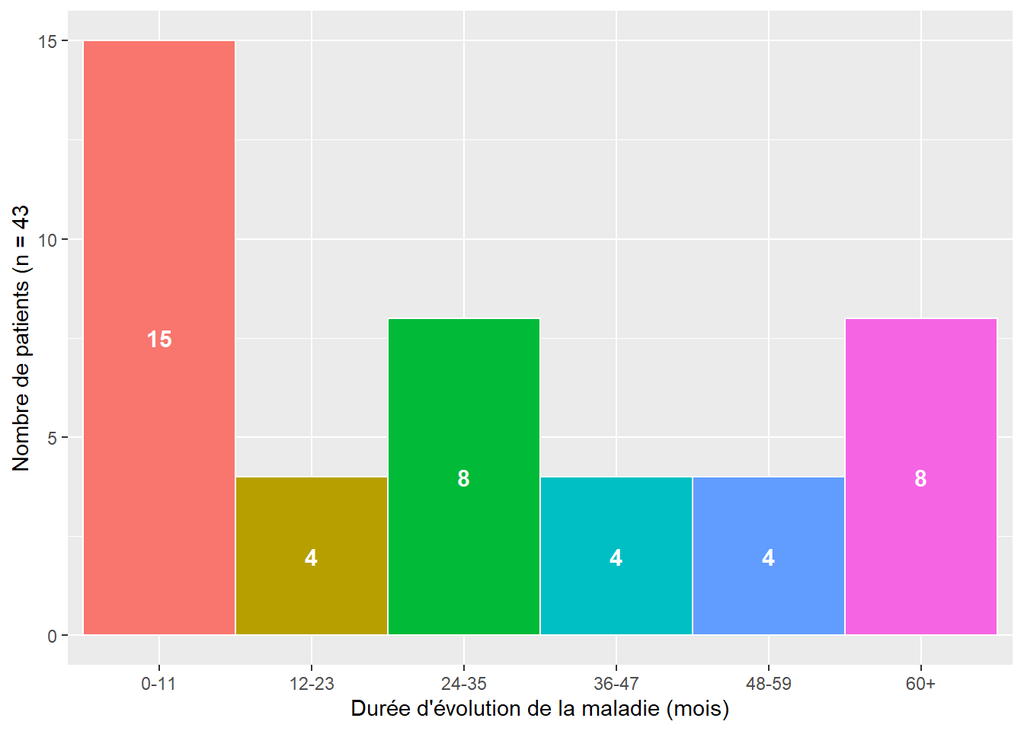

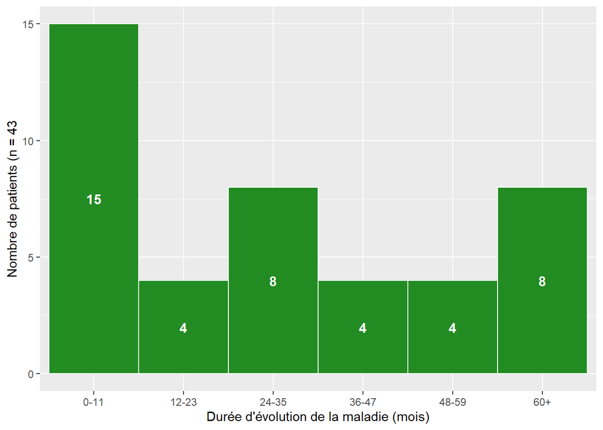

## Facteurs de risque retrouvé

```
## # A tibble: 6 × 5
##   facteurs_de_risque     n   pct  csum   pos
##   <chr>              <int> <dbl> <int> <dbl>
## 1 Aucun                 29  59.2    49  34.5
## 2 Hérédité               5  10.2    20  17.5
## 3 Non précisé            6  12.2    15  12
## 4 Obésité                5  10.2     9   6.5
## 5 Obésité Tabac          2   4.1     4   3
## 6 Tabac                  2   4.1     2   1
```

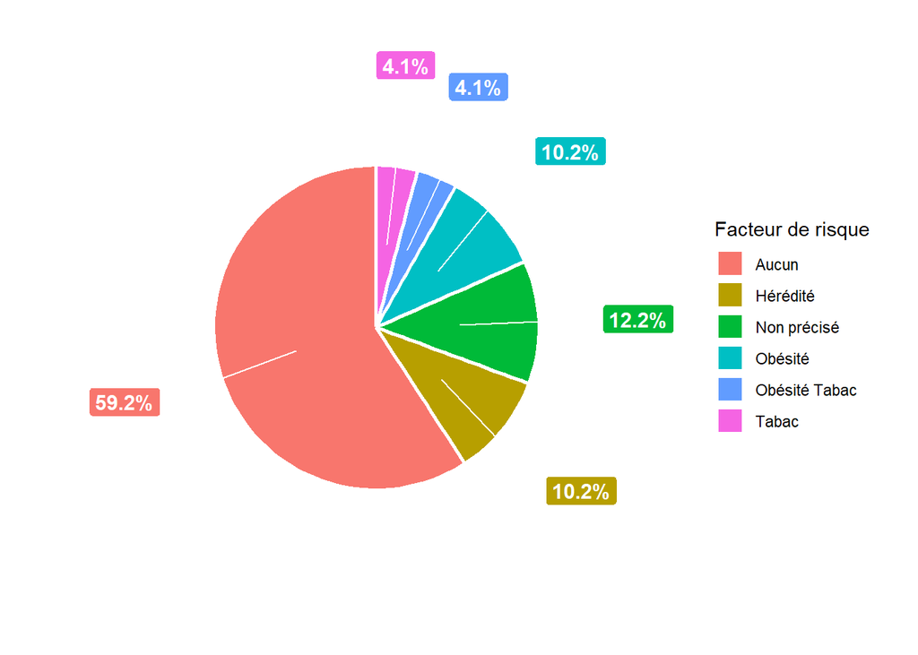

## Siège de début des lésions

```
## # A tibble: 9 × 6
##   siege_de_debut       n   pct  csum   pos siege_de_debut_ord
##   <chr>            <int> <dbl> <int> <dbl> <fct>
## 1 Aisselles           34  69.4    49  32   Aisselles
## 2 Aisselles Pubis      1   2      15  14.5 Aisselles Pubis
## 3 Aisselles Visage     1   2      14  13.5 Aisselles Visage
## 4 Fesses               2   4.1    13  12   Fesses
## 5 Non précisé          4   8.2    11   9   Non précisé
## 6 Pubis                1   2       7   6.5 Pubis
## 7 Pubis Fesses         1   2       6   5.5 Pubis Fesses
## 8 Périnée              1   2       5   4.5 Périnée
## 9 Visage               4   8.2     4   2   Visage
```

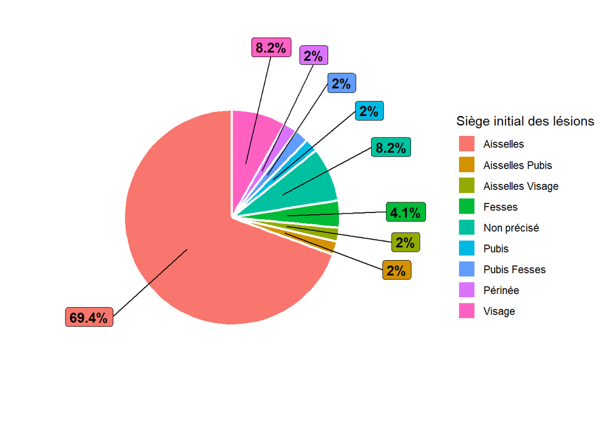

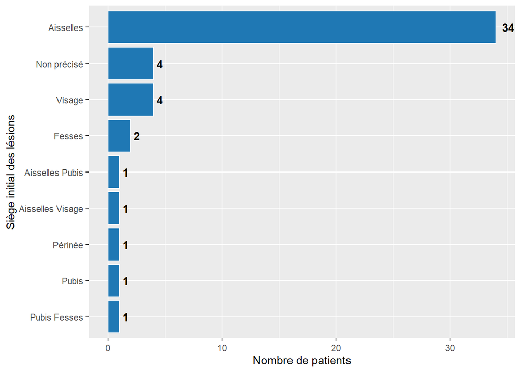

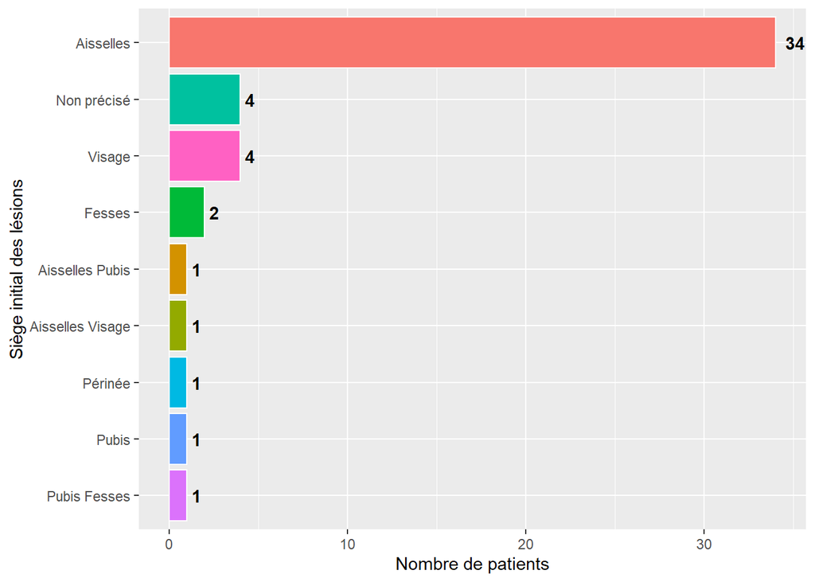

## Siège actuel des lésions

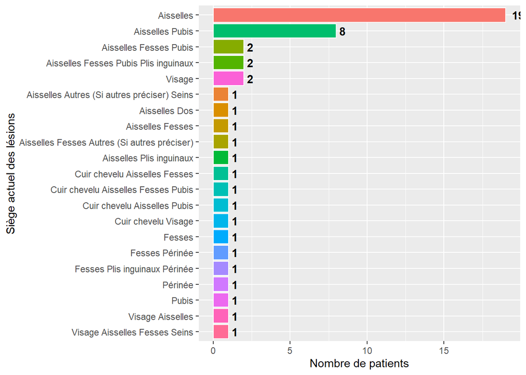

## Types de lésions

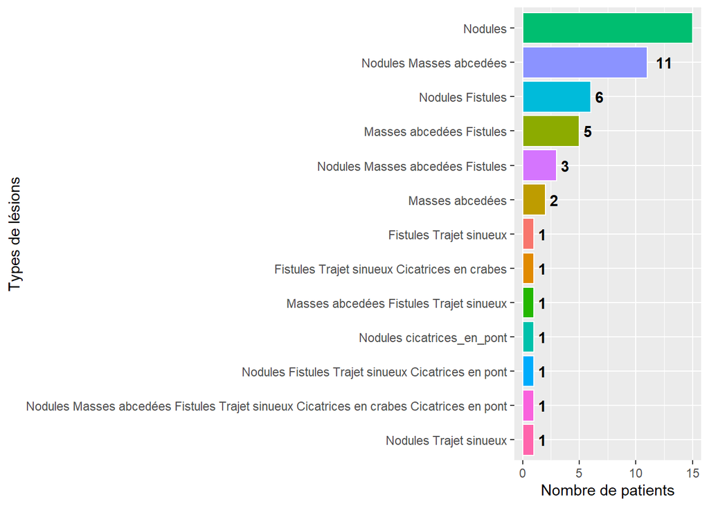

## Classification clinique de Hurley

```
## # A tibble: 3 × 5
##   classification_de_hurley     n   pct  csum   pos
##   <chr>                    <int> <dbl> <int> <dbl>
## 1 Stade 1                     28  57.1    49  35
## 2 Stade 2                     19  38.8    21  11.5
## 3 Stade 3                      2   4.1     2   1
```

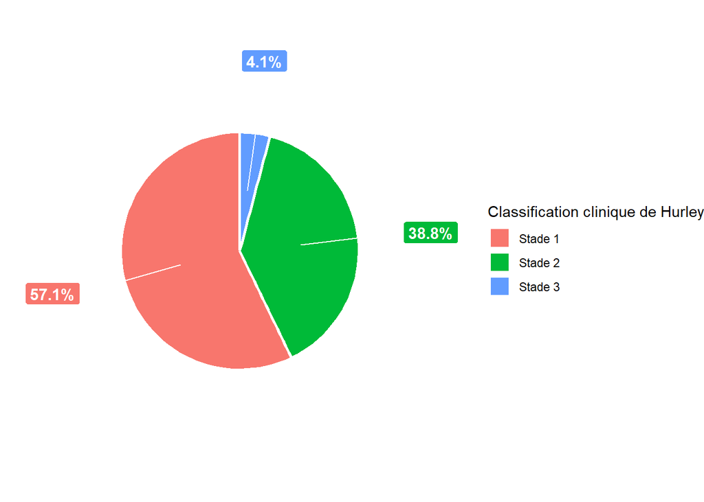

## Qualité de vie

```
##
##  Shapiro-Wilk normality test
##
## data:  mdv$total_dlqi
## W = 0.70405, p-value = 3.094e-05
```

```
##    Min. 1st Qu.  Median    Mean 3rd Qu.    Max.    NA's
##   1.000   2.000   2.000   3.714   4.000  13.000      28
```

Des 21 patients pour lesquels l’information est disponible, le score DLQI varie de 1 à 13, avec une médiane de 2 (EIQ: 2-4).

| qdv | n | pct |
| --- | --- | --- |
| Données non disponibles | 28 | 57.1 |
| Faible altération | 12 | 24.5 |
| QdV non altérée | 5 | 10.2 |
| Altération importante | 2 | 4.1 |
| Altération modérée | 2 | 4.1 |

Aucun patient ne présente une altération extrêmement importante. Cependant, 4 patients (8,2%) présentent une altération modérée à importante de la QdV. En outre, 12 patients (24,5%) présentent une faible altération de la QdV tandis que 5 patients (10,2%) ne présentent aucune altération de leur QdV.

```
## # A tibble: 5 × 5
##   qdv                         n   pct  csum   pos
##   <chr>                   <int> <dbl> <int> <dbl>
## 1 Altération importante       2   4.1    49  48
## 2 Altération modérée          2   4.1    47  46
## 3 Données non disponibles    28  57.1    45  31
## 4 Faible altération          12  24.5    17  11
## 5 QdV non altérée             5  10.2     5   2.5
```

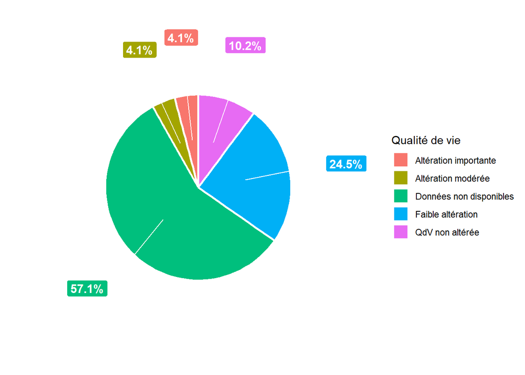

# Analyse bivariée

## Distribution de la QdV selon le sexe

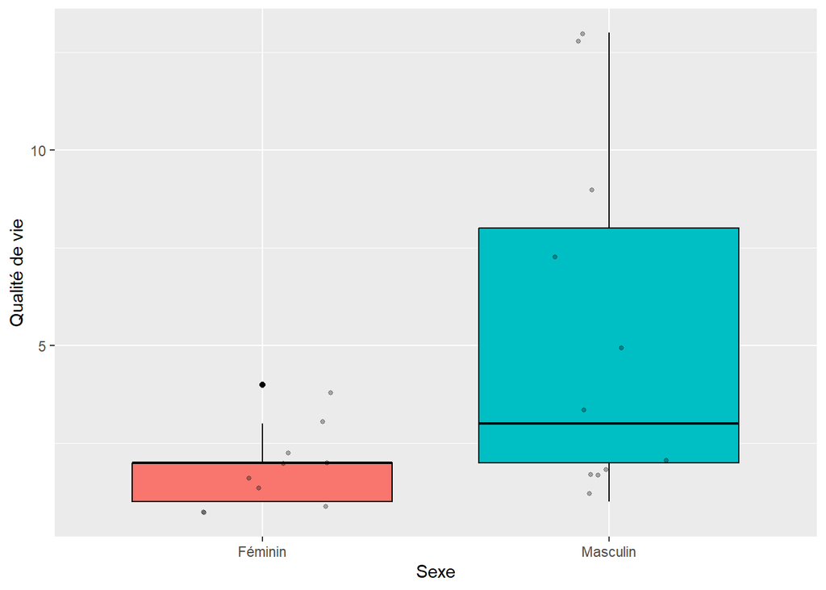

```
##
##  Wilcoxon rank sum test with continuity correction
##
## data:  total_dlqi by sexe
## W = 25.5, p-value = 0.03432
## alternative hypothesis: true location shift is not equal to 0
```

| sexe | median | first_q | third_q |
| --- | --- | --- | --- |
| Féminin | 2 | 1 | 2 |
| Masculin | 3 | 2 | 8 |

Une comparaison des scores de qualité de vie entre hommes et femmes montre que les hommes ont une tendance à une altération de qdv plus marquée que chez les femmes, avec une différence statistiquement signficative: médiane 3 (EIQ 2-8) vs 2,0 (EIQ 1-2); p = 0,034 (Figure 10).